# Strongx Data Example

Alexandra Chronopoulou

Lecture 11 & 12 Example

This is the strong interaction experiment data set from Faraway’s book. In this example, a large number of observations was taken for each measurement. That allows to have a good estimate of the standard deviation $sd$ for each value of the response at each energy level. The standard deviations have already been calculated and are part of the data set provided to us.

```r
library(faraway)
data("strongx")
names(strongx)
```

```
## [1] "momentum" "energy"   "crossx"   "sd"
```

```r
head(strongx)
```

```
##   momentum energy crossx sd
## 1        4  0.345    367 17
## 2        6  0.287    311  9
## 3        8  0.251    295  9
## 4       10  0.225    268  7
## 5       12  0.207    253  7
## 6       15  0.186    239  6
```

In this example, we know the true variances. So, we are going to use them as **weights** to run a Weighted Least Squares regression as follows:

```r
strong.weights = lm(crossx ~ energy, strongx, weights=1/sd^2)
summary(strong.weights)
```

```
##
## Call:
## lm(formula = crossx ~ energy, data = strongx, weights = 1/sd^2)
##
## Weighted Residuals:
##     Min      1Q  Median      3Q     Max
## -2.3230 -0.8842  0.0000  1.3900  2.3353
##
## Coefficients:
##             Estimate Std. Error t value Pr(>|t|)
## (Intercept)  148.473      8.079   18.38 7.91e-08 ***
## energy       530.835     47.550   11.16 3.71e-06 ***
## ---
## Signif. codes:  0 '***' 0.001 '**' 0.01 '*' 0.05 '.' 0.1 ' ' 1
##
## Residual standard error: 1.657 on 8 degrees of freedom
## Multiple R-squared:  0.9397, Adjusted R-squared:  0.9321
## F-statistic: 124.6 on 1 and 8 DF,  p-value: 3.71e-06
```

Let’s see what the results would be if we run a standard regression with no weights:

```r
strong=lm(crossx ~ energy, strongx);
summary(strong)
```

```
##
## Call:
## lm(formula = crossx ~ energy, data = strongx)
##
## Residuals:
##     Min      1Q  Median      3Q     Max
## -14.773  -9.319  -2.829   5.571  19.817
##
## Coefficients:
##             Estimate Std. Error t value Pr(>|t|)
## (Intercept)   135.00      10.08    13.4 9.21e-07 ***
## energy        619.71      47.68    13.0 1.16e-06 ***
## ---
## Signif. codes:  0 '***' 0.001 '**' 0.01 '*' 0.05 '.' 0.1 ' ' 1
##
## Residual standard error: 12.69 on 8 degrees of freedom
## Multiple R-squared:  0.9548, Adjusted R-squared:  0.9491
## F-statistic: 168.9 on 1 and 8 DF,  p-value: 1.165e-06
```

As we can observe, there is a small difference in the estimators. Let’s now take a look at the estimated variance, i.e. the $\hat{\sigma}^2$ term.

*How do we estimate $\hat{\sigma}^2$?*

In the model without weights, we have the estimator extracted from the `lm` output and the $MSE$ calculated “by hand”:

```r
cbind(summary(strong)$sig^2, sum(strong$res^2)/8)
```

```
##          [,1]     [,2]
## [1,] 161.1616 161.1616
```

These two terms coicide.

However, when we use WLS, these two estimates do not agree. In fact, they are

```r
cbind(summary(strong.weights)$sig^2, sum(strong.weights$res^2)/8)
```

```
##          [,1]     [,2]
## [1,] 2.744081 248.7354
```

If we want to estimate $\hat{\sigma}^2$ by hand, we will need to divide the residuals with the corresponding variance terms as follows:

```r
sum(strong.weights$res^2/strongx$sd^2)/8
```

```
## [1] 2.744081
```

Now, this quantity matched the estimated $\hat{\sigma}^2$ by R.

Last, let us reproduce the plot from the lectures, and plot the raw data (triangles), their corresponding standard deviations (circles around the triangles), the WLS regression line (red) and the OLS regression line (blue):

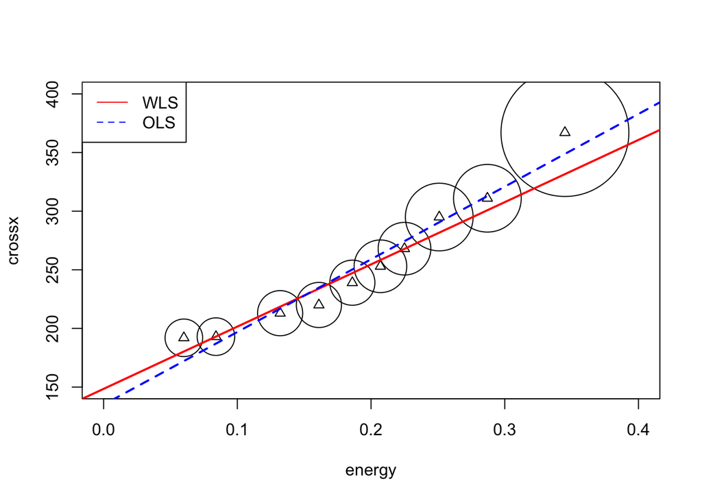

```r
plot(crossx ~ energy, data=strongx, cex=sd, xlim=c(0, 0.4), ylim=c(150, 400));
points(crossx ~ energy, data=strongx, pch=2)
abline(strong.weights, col="red", lty=1, lwd=2);
abline(strong, col="blue", lty=2, lwd=2);
legend("topleft", col=c("red", "blue"), lty=c(1,2), legend=c("WLS", "OLS"))
```

### Lack-of-Fit Test

In this example, we can also perform a lack-of-fit test. This is an example of *known* variance, since as we discussed above the SDs are given to us. In fact, we are going to perform a WLS and then do a lack-of-fit test as follows:

```r
strong.weights = lm(crossx ~ energy, strongx, weights=1/sd^2)
1 - pchisq(summary(strong.weights)$sig^2*8, 8) # Assume sigma^2=1
```

```
## [1] 0.005004345
```

As you can see, the p-value is very small, which means that we reject the null and conclude that there is lack-of-fit.